# STM32 CRC IP as shared resource

7.0.0  
STM32 CRC IP as shared resource

- [ Index ]
- Overview
- User call-back definitions
- Minimal implementation
- References

# STM32 CRC IP as shared resource

X-CUBE-AI Expansion Package

r1.0

AI PLATFORM r7.0.0 (Embedded Inference Client API 1.1.0)

Command Line Interface r1.5.1

# Overview

To use the network-runtime library, the STM32 CRC IP should be enabled (or clocked) else the application hangs. The IP is used to check that the library is effectively used on a STM32 device at each call of an `ai_<network>_xx()'` function.

By default, AI library point of view, the CRC IP is considered as an exclusive resource. Before to call an AI service, the application layer is responsible to guarantee the access of the CRC IP. If the IP is used by another SW component, it should be reserved during the call of the AI service.

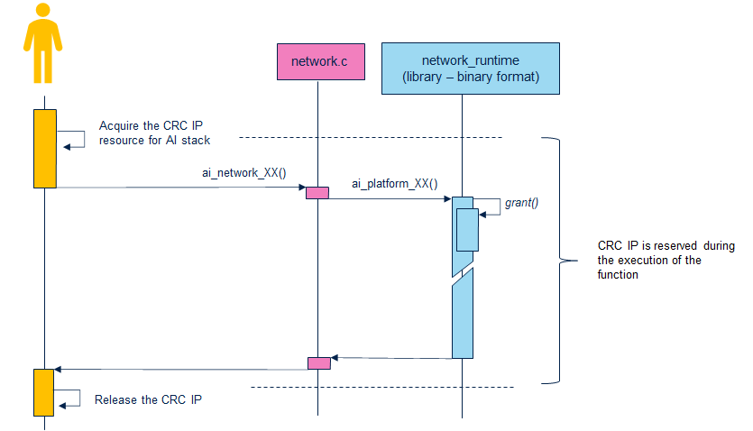

To improve the usage of the CRC IP and to consider it as a shared resource, two *optional* specific hooks or callback functions (weak functions) are defined to facilitate its usage with a resource manager.

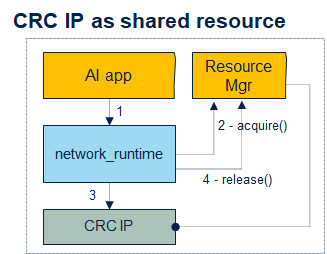

If requested, the callbacks should be implemented by the application layer to acquire and to release dynamically the accesses of the CRC IP.

# User call-back definitions

```cpp
uint32_t _ai_platform_acquire_crc(void);
```

This call-back is called by the library when the access to the CRC IP should be granted. Returns a `id` of the reserved resource, `0` indicates that the reservation has failed (no retry mechanism is in place).

```cpp
void _ai_platform_release_crc(uint32_t id);
```

This call-back is called by the library when the access to the CRC IP is no more requested. It is called with the `ìd` value.

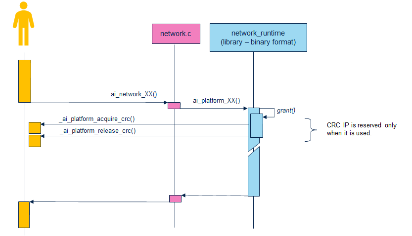

# Minimal implementation

In this example, the CRC IP is not considered as a shared resource, but it allows to enable the clock only when the IP is used.

```cpp
#include "stm32h7xx.h"   /* STM32 HAL header */

uint32_t _ai_platform_acquire_crc(void)
{
    __HAL_RCC_CRC_CLK_ENABLE();
    return 1;
}

void _ai_platform_release_crc(uint32_t id)
{
    __HAL_RCC_CRC_CLK_DISABLE();
}
```

# References

| ref | description |
| --- | --- |
| [DS] | X-CUBE-AI - AI expansion pack for STM32CubeMX https://www.st.com/en/embedded-software/x-cube-ai.html |
| [UM] | User manual - Getting started with X-CUBE-AI Expansion Package for Artificial Intelligence (AI) [(pdf)](https://www.st.com/resource/en/user_manual/dm00570145.pdf) |
| [CLI] | stm32ai - Command Line Interface (link) |
| [API] | Embedded inference client API (link) |
| [METRIC] | Evaluation report and metrics (link) |
| [TFL] | TensorFlow Lite toolbox (link) |
| [KERAS] | Keras toolbox (link) |
| [ONNX] | ONNX toolbox (link) |
| [FAQS] | FAQ generic, validation, quantization |
| [QUANT] | Quantization and quantize command (link) |
| [RELOC] | Relocatable binary network support (link) |
| [CUST] | Support of the Keras Lambda/custom layers (link) |
| [TFLM] | TensorFlow Lite for Microcontroller support (link) |
| [INST] | Setting the environment (link) |
| [OBS] | Platform Observer API (link) |
| [C-RUN] | Executing locally a generated c-model (link) |

Embedded Documentation - **STM32 CRC IP as shared resource**  
X-CUBE-AI Expansion Package  
r1.0 - AI PLATFORM r7.0.0 (Embedded Inference Client API 1.1.0) - Command Line Interface r1.5.1

Information in this document is provided solely in connection with ST products. The contents of this document are subject to change without prior notice.  
© Copyright STMicroelectronics 2020. All rights reserved. www.st.com